# Practical Machine Learning Course Project

Andrea Piccioni

11 March 2018

### Introduction

The paper [Qualitative Activity Recognition of Weight Lifting Exercises](http://groupware.les.inf.puc-rio.br/work.jsf?p1=11201) gives us a lot of information on how the observations for this exercise were built, and this helps us making few hypothesis on how the raw data could be processed before the analysis.  
The variables are logically correlated, since they are features calculated on four sensors used to track the movements on the body: mean, variance, standard deviation, max, min, amplitude, kurtosis and skewness, which generate in total 96 derived features.

### Data exploration

We load the training set and analyse its structure. The dependent variable is a factor with 5 levels and all the variables are expressed in numbers, but are classified as numeric, integers, and factors.

```r
training <- read.csv("https://d396qusza40orc.cloudfront.net/predmachlearn/pml-training.csv")
levels(training$classe)
```

```
## [1] "A" "B" "C" "D" "E"
```

```r
str(training)
```

```
## 'data.frame':    19622 obs. of  160 variables:
##  $ X                       : int  1 2 3 4 5 6 7 8 9 10 ...
##  $ user_name               : Factor w/ 6 levels "adelmo","carlitos",..: 2 2 2 2 2 2 2 2 2 2 ...
##  $ raw_timestamp_part_1    : int  1323084231 1323084231 1323084231 1323084232 1323084232 1323084232 1323084232 1323084232 1323084232 1323084232 ...
##  $ raw_timestamp_part_2    : int  788290 808298 820366 120339 196328 304277 368296 440390 484323 484434 ...
##  $ cvtd_timestamp          : Factor w/ 20 levels "02/12/2011 13:32",..: 9 9 9 9 9 9 9 9 9 9 ...
##  $ new_window              : Factor w/ 2 levels "no","yes": 1 1 1 1 1 1 1 1 1 1 ...
##  $ num_window              : int  11 11 11 12 12 12 12 12 12 12 ...
##  $ roll_belt               : num  1.41 1.41 1.42 1.48 1.48 1.45 1.42 1.42 1.43 1.45 ...
##  $ pitch_belt              : num  8.07 8.07 8.07 8.05 8.07 8.06 8.09 8.13 8.16 8.17 ...
##  $ yaw_belt                : num  -94.4 -94.4 -94.4 -94.4 -94.4 -94.4 -94.4 -94.4 -94.4 -94.4 ...
##  $ total_accel_belt        : int  3 3 3 3 3 3 3 3 3 3 ...
##  $ kurtosis_roll_belt      : Factor w/ 397 levels "","-0.016850",..: 1 1 1 1 1 1 1 1 1 1 ...
##  $ kurtosis_picth_belt     : Factor w/ 317 levels "","-0.021887",..: 1 1 1 1 1 1 1 1 1 1 ...
##  $ kurtosis_yaw_belt       : Factor w/ 2 levels "","#DIV/0!": 1 1 1 1 1 1 1 1 1 1 ...
```

[output cut: 86 more lines]

Let’s also load the testing set, which includes the same classifiers of the training set, from which differs only for the name of the outcome: this is called “problem_id” in the testing set and “classe” in the training set.

```r
testing <- read.csv("https://d396qusza40orc.cloudfront.net/predmachlearn/pml-testing.csv")
```

Looking at the structure of the data, we can see that the first columns/variables are mostly labels assigned to the samples while the measurements were collected and categorised:  
1. “X”: a serial number  
2. “user_name”: the name of who executes the exercise (6 individuals in total);  
3. “raw_timestamp_part_1”: a part of the time stamp assigned to each observation  
4. “raw_timestamp_part_2”: a part of the time stamp assigned to each observation  
5. “cvtd_timestamp”: date and time of the observation  
6. “new_window”: linked to the lag of time of the measurement  
7. “num_window”: an index linked to the lprevious parameter

Another relevant fact of the data-set is the high number of missing values for many variables.

### Preprocessing

We merge the two datasets in first place, which will allow us later on to impute missing values, to explore the correlation, and the skewness of the parameters. We will remove the first 4 columns only, as we think that the outcome should not be related to them; and we’ll exclude the dependent variable for now.

```r
train <- training[,-c(1:4,160)]
test <- testing [,-c(1:4,160)]
data <- rbind(train, test)
```

We assume that NA’s correspond to feature values not significantly different from zero, so we’ll impute a zero for each of them. In addition to that, we need to transform all the factor variables to numeric, to allow the analysis of covariances.

```r
data <- data %>%
  mutate_if(is.factor, as.numeric) %>%
  replace(., is.na(.), 0)
```

#### Correlation

We use the caret and corrplot packages to calculate and plot the correlation matrix: here only the first 30 variables were included in the graphs for more clarity.

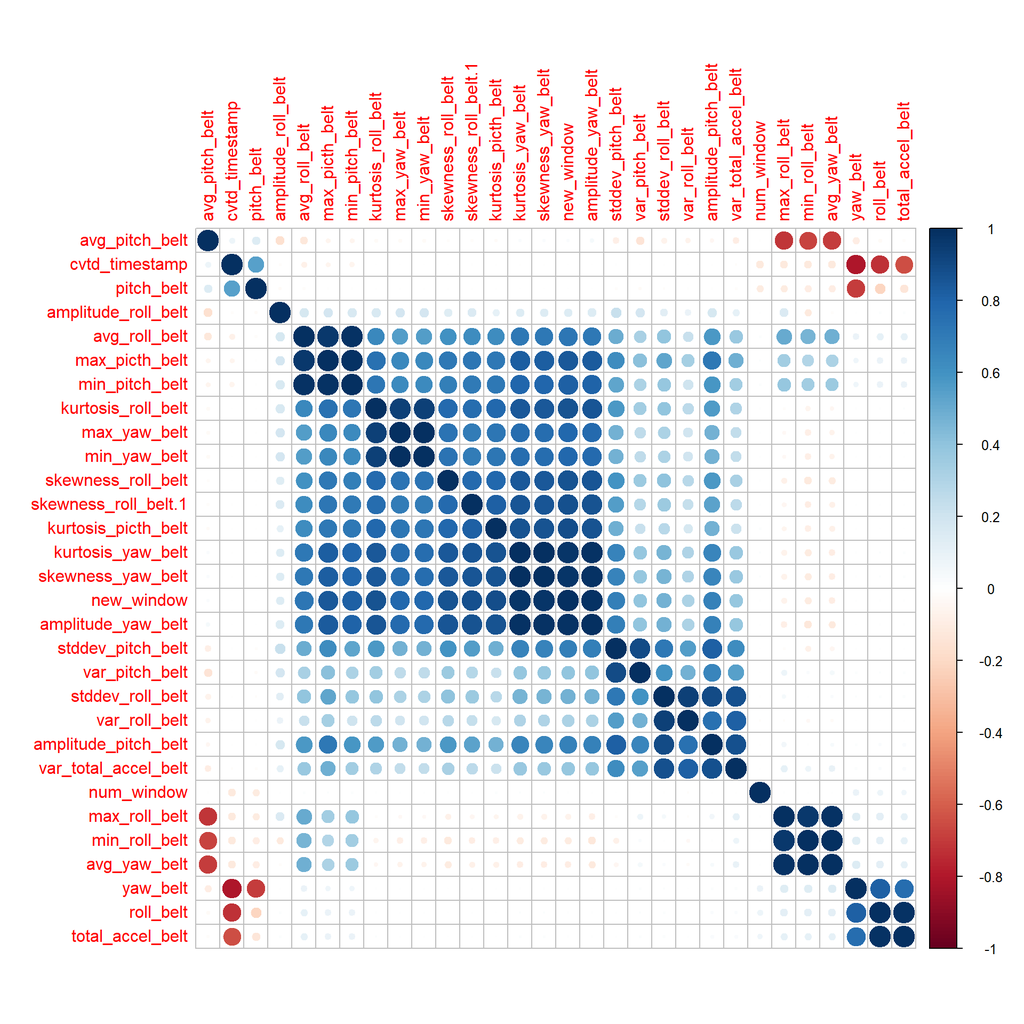

Many variables show high correlation as expected.  
We can try to minimize the incidence of those having more than a certain correlation manually: for example, we could keep only one between “standard_deviations” and “variances” for each sensor; and decide to keep “kurtosis” and remove “max” and “min”, since the first takes into account the other two.  
The alternative approach is to let R do all the job, by the findcorrelation() function in caret. For the sake of the exercise, we want to try both ways and to compare their results.

##### Manual data compression

We select the variables which include a measure of variance, maximum and minimum, and we remove them from the data-set:

```r
data1 <- data[, -grep("^var_", colnames(data))] # any variable name starting with "var"
data1 <- data1[, -grep("^min_", colnames(data))] # any variable name starting with "min"
data1 <- data1[, -grep("^max_", colnames(data))] # any variable name starting with "max"
```

Then, we let R finish the job, by choosing a correlation of 0.8 as threshold; and we plot again the correlation matrix:

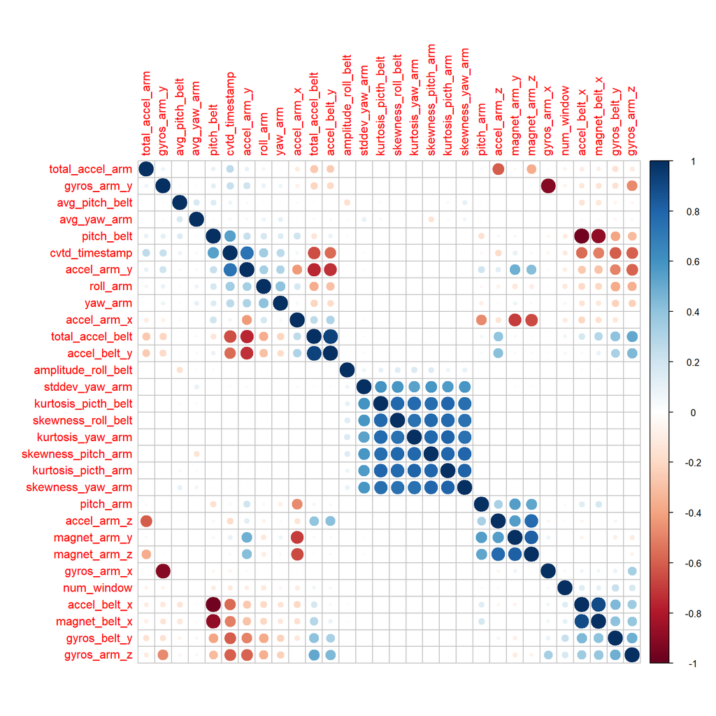

```r
highCorr1 <- findCorrelation(correlations, cutoff = 0.8)
data1 <- data1[,-highCorr1]
correlations1 <- cor(data1)
corrplot(correlations1[1:30,1:30], order = "hclust")
```

##### Automated data compression

We use the findCorrelation() function which recursively search for the highest correlated variables, one by one, to exclude any variable having correlation>0.8.

```r
highCorr <- findCorrelation(correlations, cutoff = 0.8)
```

According to the threshold, 67 variables appear to be highly correlated. We filter out these variables and have a look at the correlation matrix again.

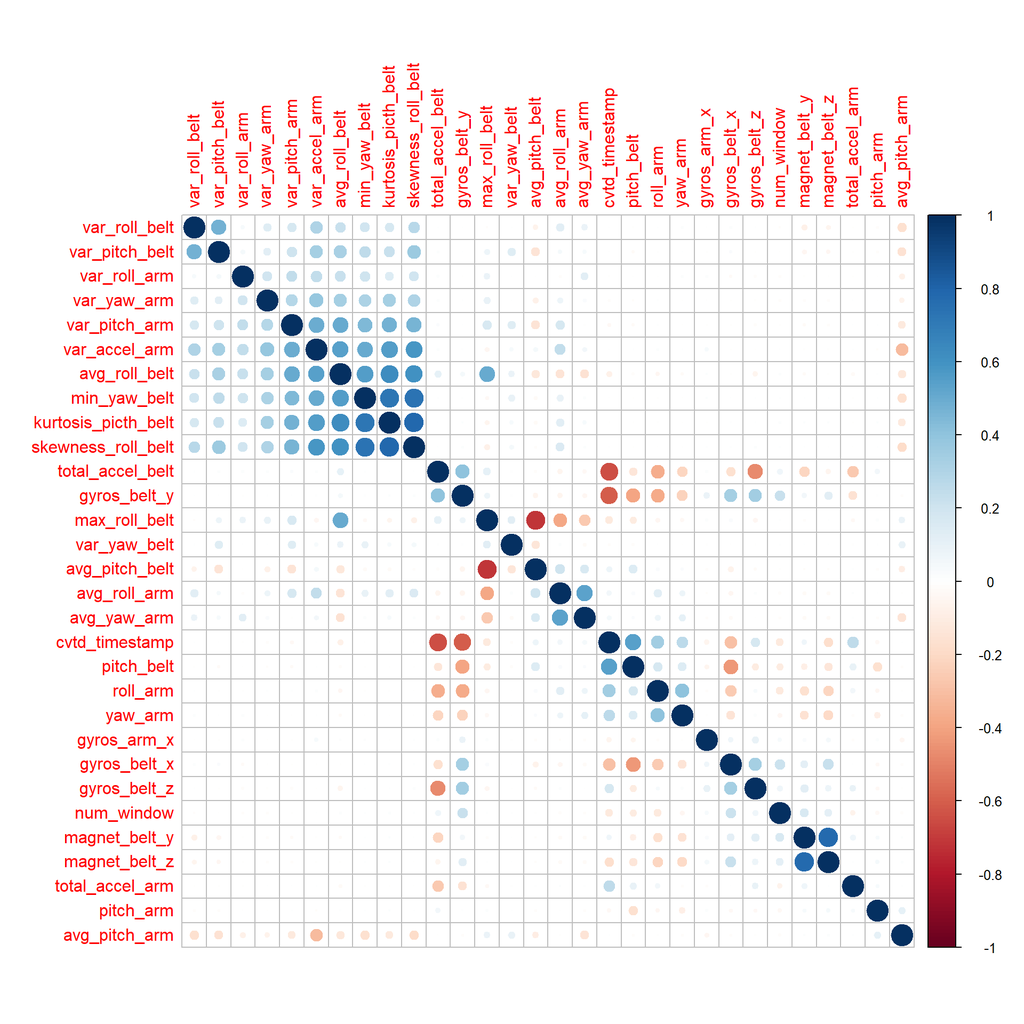

```r
data2 <- data[,-highCorr]
correlations <- cor(data2)
corrplot(correlations[1:30,1:30], order = "hclust")
```

#### Balance and Skewness of the variables

We look at how the balance in the distribution of each variable, to prevent issues related to skewness.  
Looking at the predicted variable in particular, the balance seems not to be a problem, so no downsampling should be necessary.

```
##
##    A    B    C    D    E
## 5580 3797 3422 3216 3607
```

The situation looks different for the predictors. We use the skewness function from the e1071 package, and we plot the skewness for both data-sets: the manual removal of some variables seems to have helped afterall.

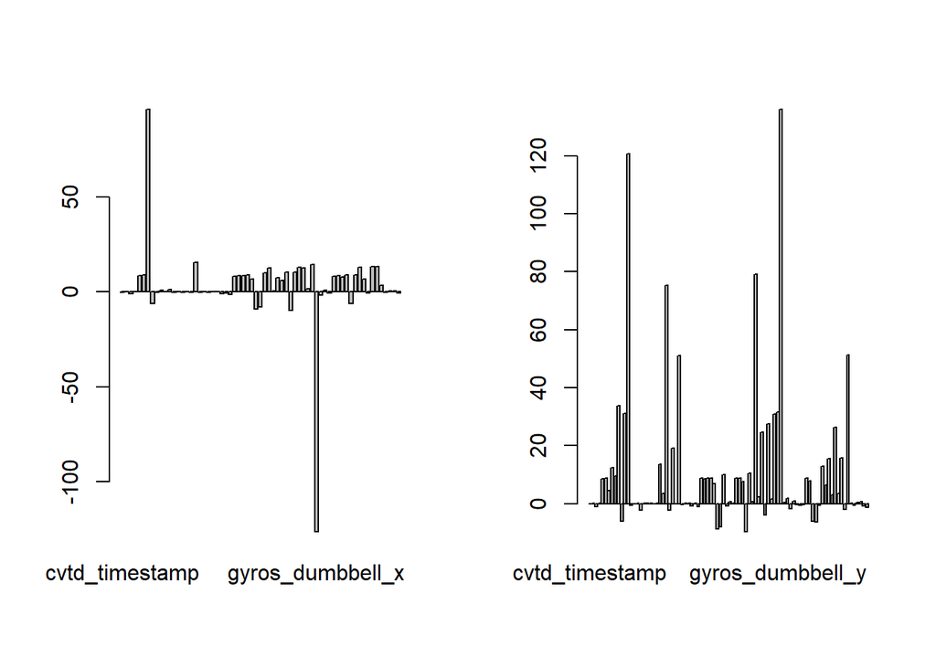

#### Data transformation

To reduce the skewness, we use the preProcess function in the caret package, by implementing the BoxCox method and a pca compression.

```r
set.seed(4321)
transData1 <- preProcess(data1,
                         method = c("BoxCox", "pca", "scale", "center"))

transData2 <- preProcess(data2,
                         method = c("BoxCox", "pca", "scale", "center"))
```

We can now apply the transformations to our data and have a look at the new plot of the skewness.

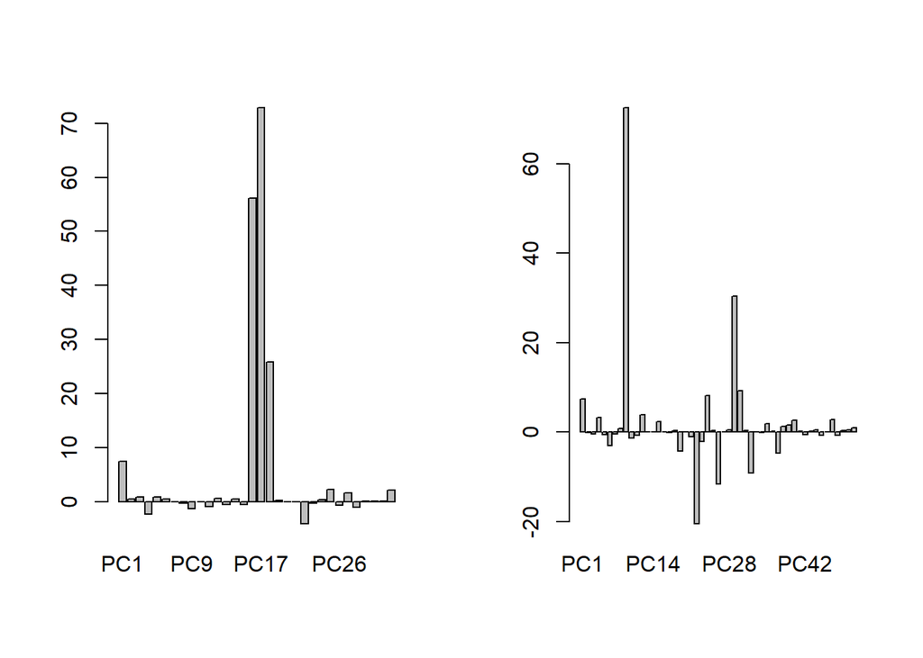

The datasets will now include respectively 32 and 51 predictors.  
We rebuild training *transTrain1* and *2* and testing sets *transTest1* and *2* for the analysis (but still keeping out the dependent variable):

```r
transTrain1 <- transformed1[1:nrow(training),]
transTest1 <- transformed1[(nrow(training)+1):nrow(transformed1),]

transTrain2 <- transformed2[1:nrow(training),]
transTest2 <- transformed2[(nrow(training)+1):nrow(transformed2),]
```

### Train the model

A support vector machine algorithm applies in cases of classification problems with a small number of parameters and an intermediate number of observations (*[Machine Learning in Coursera - by Andrew Ng](https://www.coursera.org/learn/machine-learning)*).

We will use the svm() function in e1071 with gaussian kernel and a k-fold CV of 10; and we will also measure the time of computation for both models as follows:

```r
start.time1 <- Sys.time()

y <- training$classe
x <- transTrain1
set.seed(123)
svmFit1 <- svm(x, y, scale = FALSE,
              type = "C-classification",
              cross = 10,
              kernel = "radial")

total.time1 <- Sys.time()-start.time1
summary(svmFit1)
```

```
##
## Call:
## svm.default(x = x, y = y, scale = FALSE, type = "C-classification",
##     kernel = "radial", cross = 10)
##
##
## Parameters:
##    SVM-Type:  C-classification
##  SVM-Kernel:  radial
##        cost:  1
##       gamma:  0.03125
##
## Number of Support Vectors:  11316
##
##  ( 2118 2415 2613 2160 2010 )
##
##
## Number of Classes:  5
##
## Levels:
##  A B C D E
##
## 10-fold cross-validation on training data:
##
## Total Accuracy: 87.57007
## Single Accuracies:
##  88.63405 87.05403 88.12436 87.51274 87.67193 86.49337 87.71662 87.66565 87.30887 87.5191
```

```r
start.time2 <- Sys.time()

y <- training$classe
x <- transTrain2
set.seed(123)
svmFit2 <- svm(x, y, scale = FALSE,
              type = "C-classification",
              cross = 10,
              kernel = "radial")

total.time2 <- Sys.time()-start.time2
summary(svmFit2)
```

```
##
## Call:
## svm.default(x = x, y = y, scale = FALSE, type = "C-classification",
##     kernel = "radial", cross = 10)
##
##
## Parameters:
##    SVM-Type:  C-classification
##  SVM-Kernel:  radial
##        cost:  1
##       gamma:  0.01960784
##
## Number of Support Vectors:  9278
##
##  ( 1853 2148 2099 1743 1435 )
##
##
## Number of Classes:  5
##
## Levels:
##  A B C D E
##
## 10-fold cross-validation on training data:
##
## Total Accuracy: 91.20885
## Single Accuracies:
##  91.94699 90.92762 91.48828 91.1315 91.84921 90.26504 91.18247 91.02956 91.43731 90.83036
```

The out-of-sample accuracy appears to be good across all the folds for both model fitted: precisely, the total accuracy is 87.5700744 for the first model, and 91.2088472 for the second one; while the time to compute is slightly less (6.1254699 minutes) for the first model, compared to the second one (7.271235 minutes).

### Prediction

We apply each model to the testing data-set and we plot a table to see the differences.

```
##       preds2
## preds1 A B C D E
##      A 7 0 1 0 0
##      B 0 7 0 0 0
##      C 0 0 1 0 0
##      D 0 0 0 1 0
##      E 0 0 0 0 3
```

The two models predict almost the same classes for the 20 testing observations.  
In conclusion, they appear identical if we look at their total accuracy in predicting the outcomes.

```
##      Accuracy     Kappa AccuracyLower AccuracyUpper AccuracyNull
## [1,]     0.95 0.9277978     0.7512672     0.9987349          0.4
## [2,]     0.95 0.9293286     0.7512672     0.9987349          0.4
##      AccuracyPValue McnemarPValue
## [1,]   3.408486e-07           NaN
## [2,]   3.408486e-07           NaN
```